# LD analysis

Sarah Mueller

2025-final

## Snp-Meth Loci

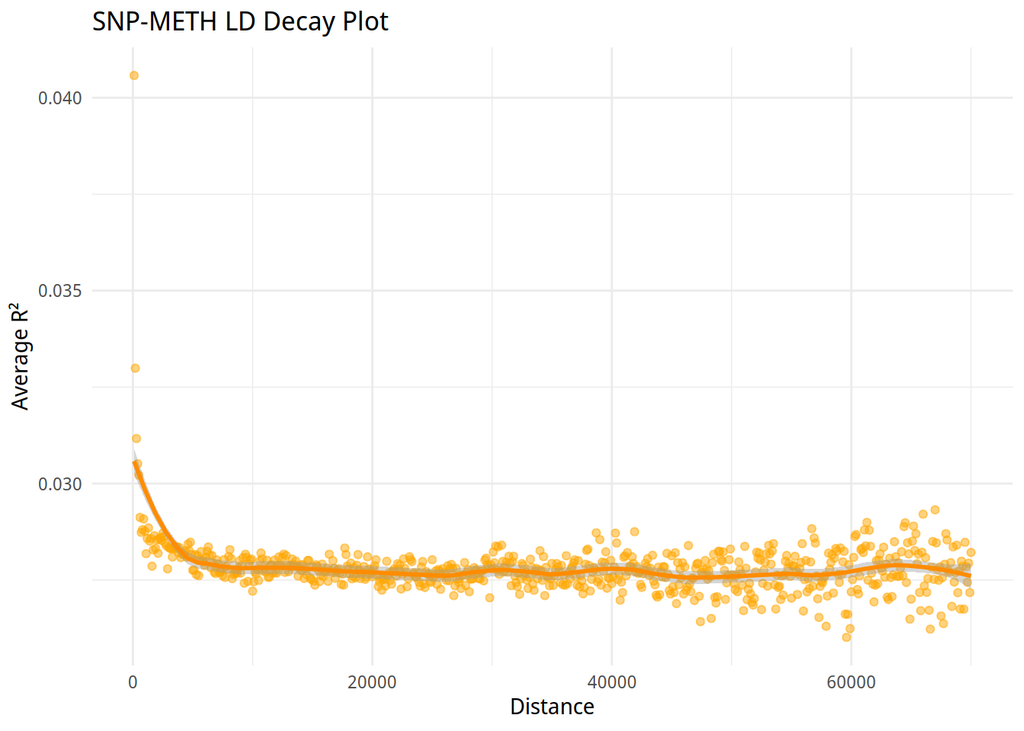

```r
snp.meth <- read.table("/dss/dsslegfs01/pr53da/pr53da-dss-0034/projects/2021_SwallowRRBS/3_Linkage/1_Rall/HR_Rall_snp.meth.maf2.ldwin100.gz", header= T)

snp.meth.ld <- snp.meth %>%
  mutate(distance=abs(BP_A - BP_B))

#there are a few loci that made it past the filters, but are still in the CpG context and therefore shoudl not be included
snp.meth.ld <- snp.meth.ld %>%
  filter(!distance == 0) %>%
  filter(!(distance == 1 & startsWith(SNP_A, "M_")))

snp.meth.ld.70kb <- snp.meth.ld %>%
  mutate(distance_bin = cut(distance,
                            breaks = seq(0, 70000, by = 100),
                            labels = seq(100, 70000, by = 100),
                            right = TRUE)) %>%
  mutate(distance_bin = as.numeric(as.character(distance_bin))) %>%  # Convert factor to numeric
  group_by(distance_bin) %>%
  summarise(avg_R2 = mean(R2, na.rm = TRUE), .groups = "drop")

snp.meth.ld.5kb <- snp.meth.ld %>%
  mutate(distance_bin = cut(distance,
                            breaks = seq(0, 5000, by = 20),
                            labels = seq(20, 5000, by = 20),
                            right = TRUE)) %>%
  mutate(distance_bin = as.numeric(as.character(distance_bin))) %>%  # Convert factor to numeric
  group_by(distance_bin) %>%
  summarise(avg_R2 = mean(R2, na.rm = TRUE), .groups = "drop")

ggplot(snp.meth.ld.70kb, aes(x = distance_bin, y = avg_R2)) +
  geom_point(alpha = 0.5, color = "orange") +  # Scatterplot of points
  geom_smooth(method = "loess", se = TRUE, color = "darkorange", span = 0.2) +  # Smoothed trend line
  #facet_wrap(~chr)+
  labs(title = "SNP-METH LD Decay Plot",
       x = "Distance",
       y = "Average R²") +
  theme_minimal()
```

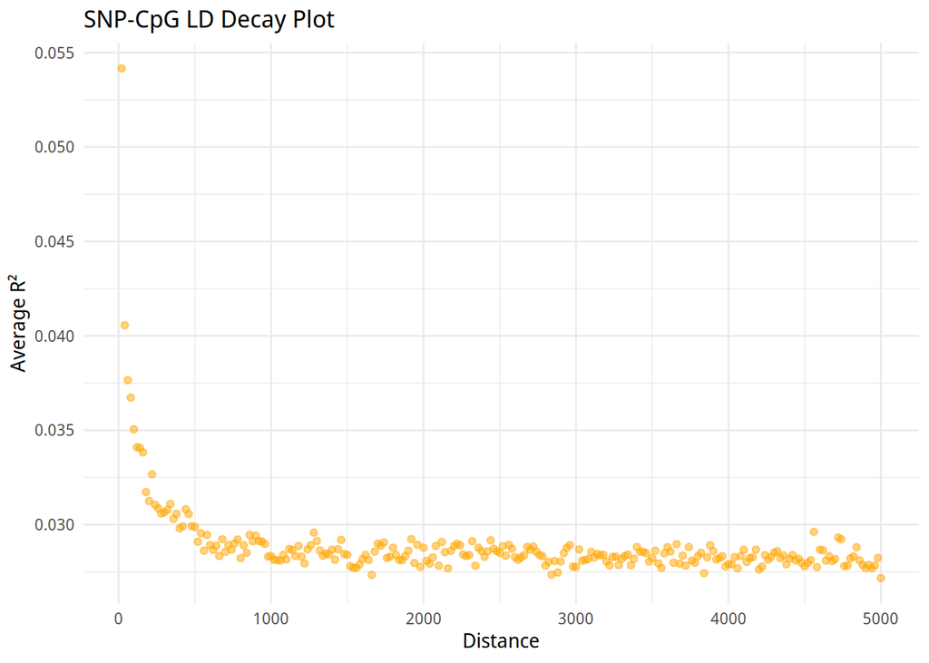

```r
ggplot(snp.meth.ld.5kb, aes(x = distance_bin, y = avg_R2), na.rm=F) +
  geom_point(alpha = 0.5, color = "orange") +  # Scatterplot of points
  #geom_smooth(method = "loess", se = TRUE, color = "darkorange", span = 0.2) +  # Smoothed trend line
  #facet_wrap(~chr)+
  labs(title = "SNP-CpG LD Decay Plot",
       x = "Distance",
       y = "Average R²") +
  theme_minimal()
```

```r
##Examine this first bin of SNP-Meth LD
snp.meth.dist20 <- snp.meth.ld %>%
  filter(distance < 20)

##Write these sites out to a table, pull them from the VCF and see the end to look in-depth at these SNP-Meth comparisons - Need to make sure the SNPs are outside of the CpG context
#write.table(dist1, "/dss/dsslegfs01/pr53da/pr53da-dss-0034/projects/2021_SwallowRRBS/3_Linkage/1_Rall/HR.85.dist1.txt", quote=F, row.names=F)
```

## Snp-Snp LD

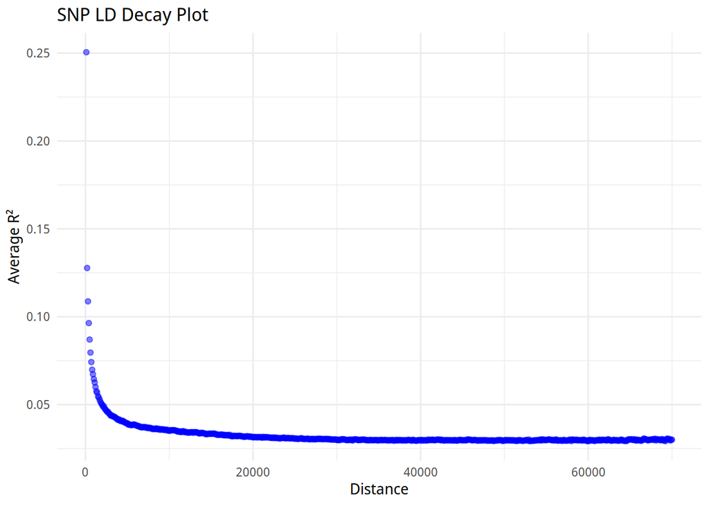

```r
snp.ld <- read.table("/dss/dsslegfs01/pr53da/pr53da-dss-0034/projects/2021_SwallowRRBS/3_Linkage/1_Rall/HR_Rall_snp.maf2.ldwin100.gz", header= F)
colnames(snp.ld) <- c("CHR_A", "BP_A", "SNP_A", "CHR_B",  "BP_B", "SNP_B", "R2") #colnames(snp.meth.ld[1:7])

snp.ld <- snp.ld %>%
  mutate(distance=abs(BP_A - BP_B))

snp.ld.70kb <- snp.ld %>%
  mutate(distance_bin = cut(distance,
                            breaks = seq(0, 70000, by = 100),
                            labels = seq(100, 70000, by = 100),
                            right = TRUE)) %>%
  mutate(distance_bin = as.numeric(as.character(distance_bin))) %>%  # Convert factor to numeric
  group_by(distance_bin) %>%
  summarise(avg_R2 = mean(R2, na.rm = TRUE), .groups = "drop")

snp.ld.5kb <- snp.ld %>%
  mutate(distance_bin = cut(distance,
                            breaks = seq(0, 5000, by = 20),
                            labels = seq(20, 5000, by = 20),
                            right = TRUE)) %>%
  mutate(distance_bin = as.numeric(as.character(distance_bin))) %>%  # Convert factor to numeric
  group_by(distance_bin) %>%
  summarise(avg_R2 = mean(R2, na.rm = TRUE), .groups = "drop")

ggplot(snp.ld.70kb, aes(x = distance_bin, y = avg_R2)) +
  geom_point(alpha = 0.5, color = "blue") +  # Scatterplot of points
  #geom_smooth(method = "loess", se = FALSE, color = "red", span = 0.2) +  # Smoothed trend line
  #facet_wrap(~chr)+
  labs(title = "SNP LD Decay Plot",
       x = "Distance",
       y = "Average R²") +
  theme_minimal()
```

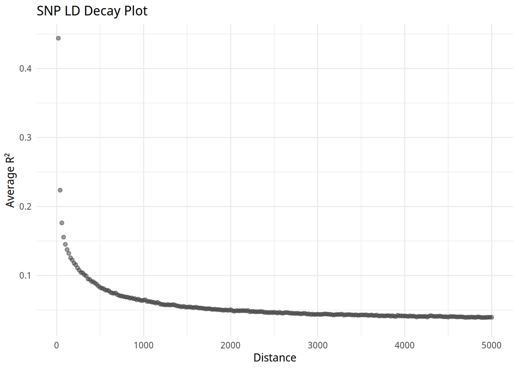

```r
ggplot(snp.ld.5kb, aes(x = distance_bin, y = avg_R2), na.rm=F) +
  geom_point(alpha = 0.5, color = "grey22") +  # Scatterplot of points
  #geom_smooth(method = "loess", se = FALSE, color = "red", span = 0.2) +  # Smoothed trend line
  #facet_wrap(~chr)+
  labs(title = "SNP LD Decay Plot",
       x = "Distance",
       y = "Average R²") +
  theme_minimal()
```

## Meth-Meth LD

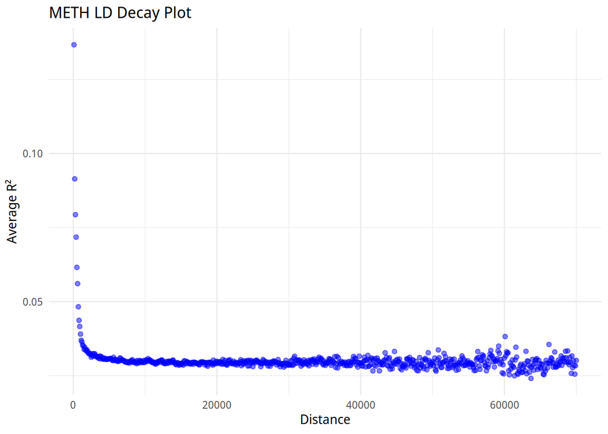

```r
meth.ld <- read.table("/dss/dsslegfs01/pr53da/pr53da-dss-0034/projects/2021_SwallowRRBS/3_Linkage/1_Rall/HR_Rall_meth.maf2.ldwin100.gz", header= F)
colnames(meth.ld) <- c("CHR_A", "BP_A", "SNP_A", "CHR_B",  "BP_B", "SNP_B", "R2")

meth.ld <- meth.ld %>%
  mutate(distance=abs(BP_A - BP_B))

meth.ld.70kb <- meth.ld %>%
  mutate(distance_bin = cut(distance,
                            breaks = seq(0, 70000, by = 100),
                            labels = seq(100, 70000, by = 100),
                            right = TRUE)) %>%
  mutate(distance_bin = as.numeric(as.character(distance_bin))) %>%  # Convert factor to numeric
  group_by(distance_bin) %>%
  summarise(avg_R2 = mean(R2, na.rm = TRUE), .groups = "drop")

meth.ld.5kb <- meth.ld %>%
  mutate(distance_bin = cut(distance,
                            breaks = seq(0, 5000, by = 20),
                            labels = seq(20, 5000, by = 20),
                            right = TRUE)) %>%
  mutate(distance_bin = as.numeric(as.character(distance_bin))) %>%  # Convert factor to numeric
  group_by(distance_bin) %>%
  summarise(avg_R2 = mean(R2, na.rm = TRUE), .groups = "drop")

ggplot(meth.ld.70kb, aes(x = distance_bin, y = avg_R2)) +
  geom_point(alpha = 0.5, color = "blue") +  # Scatterplot of points
  #geom_smooth(method = "loess", se = FALSE, color = "red", span = 0.2) +  # Smoothed trend line
  #facet_wrap(~chr)+
  labs(title = "METH LD Decay Plot",
       x = "Distance",
       y = "Average R²") +
  theme_minimal()
```

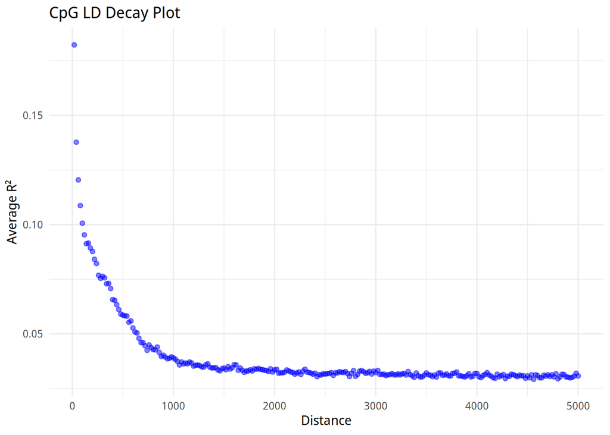

```r
ggplot(meth.ld.5kb, aes(x = distance_bin, y = avg_R2), na.rm=F) +
  geom_point(alpha = 0.5, color = "blue") +  # Scatterplot of points
  #geom_smooth(method = "loess", se = FALSE, color = "red", span = 0.2) +  # Smoothed trend line
  #facet_wrap(~chr)+
  labs(title = "CpG LD Decay Plot",
       x = "Distance",
       y = "Average R²") +
  theme_minimal()
```

## Add each one into a combined plot

```r
df_list <- list(snp.meth = snp.meth.ld.5kb, snp = snp.ld.5kb, meth = meth.ld.5kb)

snp.meth.combo.5kb <- bind_rows(lapply(names(df_list), function(name) {
  df_list[[name]] %>% mutate(Type = name)
}))

print(snp.meth.combo.5kb)
```

```
## # A tibble: 753 × 3
##    distance_bin avg_R2 Type
##           <dbl>  <dbl> <chr>
##  1           20 0.0542 snp.meth
##  2           40 0.0406 snp.meth
##  3           60 0.0377 snp.meth
##  4           80 0.0367 snp.meth
##  5          100 0.0351 snp.meth
##  6          120 0.0341 snp.meth
##  7          140 0.0341 snp.meth
##  8          160 0.0338 snp.meth
##  9          180 0.0317 snp.meth
## 10          200 0.0313 snp.meth
## # … with 743 more rows
```

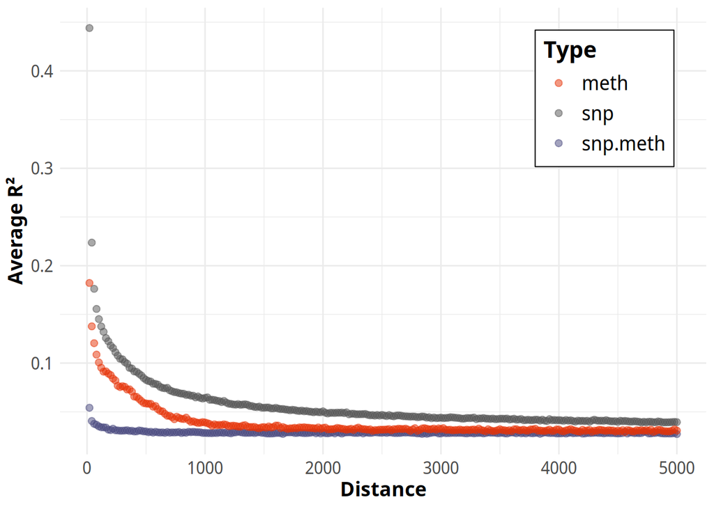

```r
ggplot(snp.meth.combo.5kb, aes(x = distance_bin, y = avg_R2, color= Type), na.rm=F) +
  geom_point(alpha = 0.5, size=2) +  # Scatterplot of points
  #geom_smooth(method = "loess", se = FALSE, span = 0.2) +  # Smoothed trend line
  scale_color_manual(values= c("#e53207", "grey33", "#48497e"))+
  labs(title = "Linkage (5kb)",
       x = "Distance",
       y = "Average R²") +
  theme_minimal() +
  theme(legend.key.size = unit(0.75, "cm"), # Adjust size as needed
        legend.text = element_text(size = 14),
        legend.position = c(.95, .95),
        legend.justification = c("right", "top"),
        legend.box.just = "right",
        legend.box.background = element_rect(fill = "white", color = "black"),
        legend.margin = margin(6, 6, 6, 6),
        legend.title = element_text(face = "bold", size=16),
        axis.text=element_text(size=12),
        axis.title=element_text(size=14,face="bold"),
        plot.title = element_blank())
```

Add on other datasets to look at which regions these high LD loci are in and how this compares to SNP and Methylation LD

```r
##Methylation LD plots
meth.info <- read.table("/dss/dsslegfs01/pr53da/pr53da-dss-0034/projects/2021_SwallowRRBS/0_Pre-processing/4_methyl_calling/0_all_sites/85.20miss/prop.85.merged.20miss.rmlowv.rmout.txt", header=T)
meth.df <- meth.info %>%
        separate(site.id, into = c("chr", "pos"), sep= "_")
meth.df$pos <- as.numeric(meth.df$pos)

##add region information and PST
pst_homer <- read.delim("/dss/dsslegfs01/pr53da/pr53da-dss-0034/projects/2021_SwallowRRBS/2_Divergence/1_PST_FST_gw/1_pst_homer/1_pst_homer_loci_85_20miss.txt", header=T)
pst_homer_df <- pst_homer %>%
  separate(site.id, into = c("chr", "pos"), sep= "_")
pst_homer_df$pos <- as.numeric(pst_homer_df$pos)
```

##Over-represented Regions (Meth-Meth LD) Create a dataframe that has the high LD loci for Meth-Meth comparisons

```r
meth.ld <- meth.ld %>%
  filter(distance < 20000)

meth.ld <- meth.ld %>%
  mutate(
    CHR_A = case_when(
      CHR_A %in% c('chr01A', 'chr04A') ~ CHR_A,
      CHR_A %in% as.character(1:9) ~ paste0('chr0', CHR_A),
      TRUE ~ paste0('chr', CHR_A)
    ),
    CHR_B = case_when(
      CHR_B %in% c('chr01A', 'chr04A') ~ CHR_B,
      CHR_B %in% as.character(1:9) ~ paste0('chr0', CHR_B),
      TRUE ~ paste0('chr', CHR_B)
    ),
    distance = (BP_B - BP_A)
  )

meth.merged.ld.a <- meth.ld %>%
      left_join(pst_homer_df, by = c("CHR_A" = "chr", "BP_A" = "pos"))
meth.merged.ld.a.b <- meth.merged.ld.a %>%
  left_join(pst_homer_df, by = c("CHR_B" = "chr", "BP_B" = "pos"))

#get just high ld sites
meth.merged.ld.a.b.highld <- meth.merged.ld.a.b %>%
      filter(R2 > 0.2)

write.table(meth.merged.ld.a.b.highld, file= "2_Rall_meth_maf2.ldwin100.r2.homer.txt", row.names=F, quote=F, sep="\t")
```

I want to compare what regions are present in the high LD dataframe and compare this to the overall dataframe. Are there regions that show a higher LD than others

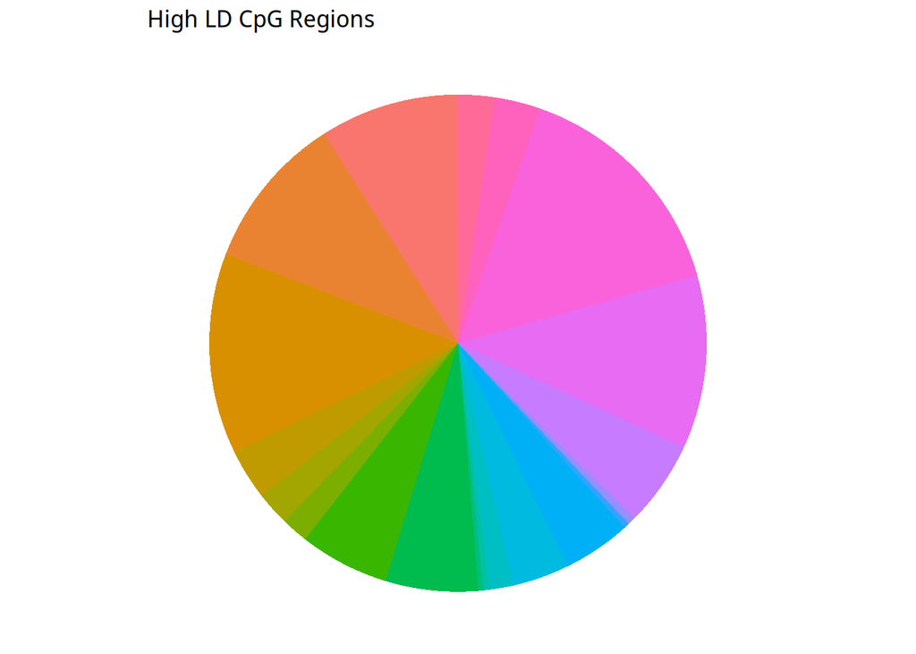

```r
# Count occurrences of total data
meth_ld_counts <- meth.merged.ld.a.b %>%
  dplyr::count(category.y)

#Count occurances in high LD data
meth_highld_counts <- meth.merged.ld.a.b.highld %>%
  dplyr::count(category.y)

# Pie Chart for `sea`
p2 <- ggplot(meth_ld_counts, aes(x = "", y = n, fill = category.y)) +
  geom_bar(stat = "identity", width = 1) +
  coord_polar(theta = "y") +
  labs(title = "High LD CpG Regions") +
  theme_void()  +
  theme(legend.position = "none")

p3 <- ggplot(meth_highld_counts, aes(x = "", y = n, fill = category.y)) +
  geom_bar(stat = "identity", width = 1) +
  coord_polar(theta = "y") +
  labs(title = "High LD CpG Regions") +
  theme_void()


p2
```

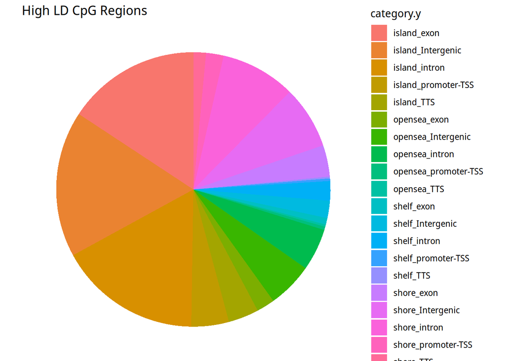

```r
p3
```

Above was a combination of island and region, now I want to look at each separately

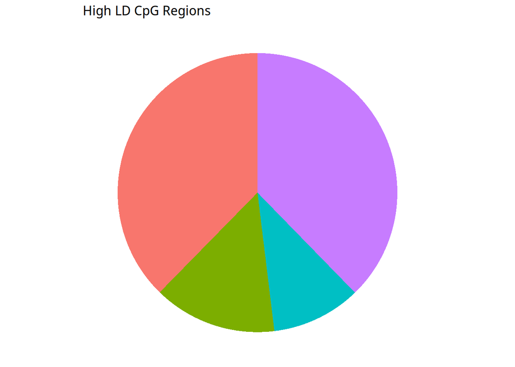

```r
###JUST region and annotation
meth.merged.ld.a.b <- meth.merged.ld.a.b %>%
  separate(Annotation.x, into = c("sea", "region"), sep = "_", remove = FALSE)
meth.merged.ld.a.b.highld <- meth.merged.ld.a.b.highld %>%
  separate(Annotation.x, into = c("sea", "region"), sep = "_", remove = FALSE)

# Count occurrences of total data
meth_ld_sea <- meth.merged.ld.a.b %>%
  dplyr::count(sea)

#Count occurances in high LD data
meth_highld_sea <- meth.merged.ld.a.b.highld %>%
  dplyr::count(sea)

# Pie Chart for `sea`
p4 <- ggplot(meth_ld_sea, aes(x = "", y = n, fill = sea)) +
  geom_bar(stat = "identity", width = 1) +
  coord_polar(theta = "y") +
  labs(title = "High LD CpG Regions") +
  theme_void()  +
  theme(legend.position = "none")

p5 <- ggplot(meth_highld_sea, aes(x = "", y = n, fill = sea)) +
  geom_bar(stat = "identity", width = 1) +
  coord_polar(theta = "y") +
  labs(title = "High LD CpG Regions") +
  theme_void()


p4
```

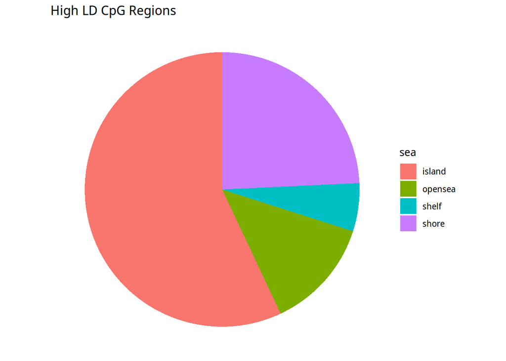

```r
p5
```

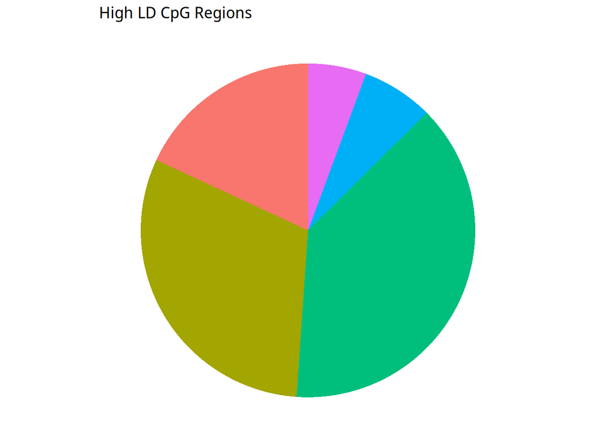

```r
# Count occurrences of total data
meth_ld_region <- meth.merged.ld.a.b %>%
  dplyr::count(region)

#Count occurances in high LD data
meth_highld_region <- meth.merged.ld.a.b.highld %>%
  dplyr::count(region)

# Pie Chart for `sea`
p6 <- ggplot(meth_ld_region, aes(x = "", y = n, fill = region)) +
  geom_bar(stat = "identity", width = 1) +
  coord_polar(theta = "y") +
  labs(title = "High LD CpG Regions") +
  theme_void()  +
  theme(legend.position = "none")

p7 <- ggplot(meth_highld_region, aes(x = "", y = n, fill = region)) +
  geom_bar(stat = "identity", width = 1) +
  coord_polar(theta = "y") +
  labs(title = "High LD CpG Regions") +
  theme_void()


p6
```

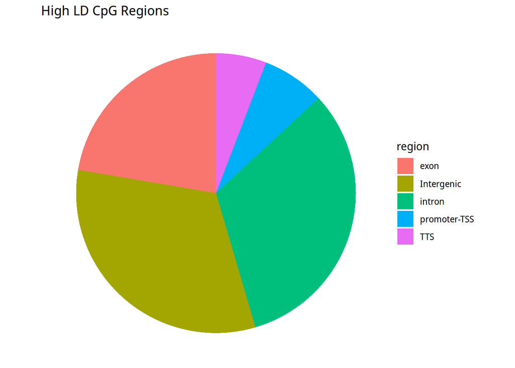

```r
p7
```

It does seems like some regions show overall higher LD values than others. Theerfore, I want to look at how this breaks-down by distance between loci. Theerfore, I will make a binned plot for each region

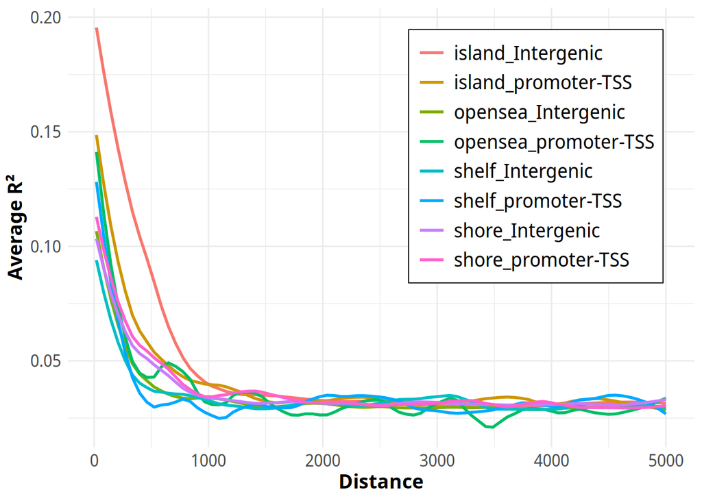

```r
###Calculate bins based on region
meth.ld.5kb.category <- meth.merged.ld.a.b %>%
  mutate(distance_bin = cut(distance,
                            breaks = seq(0, 5000, by = 20),
                            labels = seq(20, 5000, by = 20),
                            right = TRUE)) %>%
  mutate(distance_bin = as.numeric(as.character(distance_bin))) %>%
  group_by(distance_bin, category.x) %>% # Group by both distance_bin AND category
  summarise(avg_R2 = mean(R2, na.rm = TRUE), .groups = "drop")


meth.ld.5kb.category <- meth.ld.5kb.category %>%
          filter(!category.x %in% c("island_TTS", "island_exon", "island_intron", "opensea_TTS", "opensea_exon", "opensea_intron", "shelf_TTS", "shelf_exon", "shelf_intron", "shore_TTS", "shore_exon", "shore_intron", "NA"))

ggplot(meth.ld.5kb.category, aes(x = distance_bin, y = avg_R2, color= category.x), na.rm=F) +
  #geom_point(alpha = 0.5, size=2) +  # Scatterplot of points
  geom_smooth(method = "loess", se = FALSE, span = 0.2) +  # Smoothed trend line
  #scale_color_manual(values= c("#e53207", "grey33", "#48497e"))+
  labs(title = "Linkage (5kb)",
       x = "Distance",
       y = "Average R²") +
  theme_minimal() +
  theme(legend.key.size = unit(0.75, "cm"), # Adjust size as needed
        legend.text = element_text(size = 14),
        legend.position = c(.95, .95),
        legend.justification = c("right", "top"),
        legend.box.just = "right",
        legend.box.background = element_rect(fill = "white", color = "black"),
        legend.margin = margin(6, 6, 6, 6),
        legend.title = element_blank(),
        axis.text=element_text(size=12),
        axis.title=element_text(size=14,face="bold"),
        plot.title = element_blank())
```

##Over-represented Regions (SNP-Meth LD) I want to run the same analyses as above with the SNP-Meth dataset. Does this differ from the Meth-Meth linkage? First, create the high LD data

```r
#Only keep under 20,000 bp since LD is clearly below 10,000 to reduce number of loci used for comparisons. I have checked, and does not impact results
#snp.meth.ld <- snp.meth.ld %>%
#  filter(distance < 20000)

snp.meth.ld <- snp.meth.ld %>%
  mutate(
    CHR_A = case_when(
      CHR_A %in% c('chr01A', 'chr04A') ~ CHR_A,
      CHR_A %in% as.character(1:9) ~ paste0('chr0', CHR_A),
      TRUE ~ paste0('chr', CHR_A)
    ),
    CHR_B = case_when(
      CHR_B %in% c('chr01A', 'chr04A') ~ CHR_B,
      CHR_B %in% as.character(1:9) ~ paste0('chr0', CHR_B),
      TRUE ~ paste0('chr', CHR_B)
    ),
    distance = (BP_B - BP_A)
  )

snp.meth.merged.ld.a <- snp.meth.ld %>%
  inner_join(pst_homer_df, by = c("CHR_A" = "chr", "BP_A" = "pos"))
snp.meth.merged.ld.b <- snp.meth.ld %>%
  inner_join(pst_homer_df, by = c("CHR_B" = "chr", "BP_B" = "pos"))

snp.meth.merged.ld.a.b <- rbind(snp.meth.merged.ld.a, snp.meth.merged.ld.b)

#get just high ld sites
snp.meth.merged.ld.a.b.highld <- snp.meth.merged.ld.a.b %>%
  filter(R2 > 0.2)

write.table(snp.meth.merged.ld.a.b.highld, file= "2_Rall_snp_meth_maf2.ldwin100.highld.homer.txt", row.names=F, quote=F, sep="\t")
```

I want to compare what regions are present in the high LD dataframe and compare this to the overall dataframe. Are there regions that show a higher LD than others

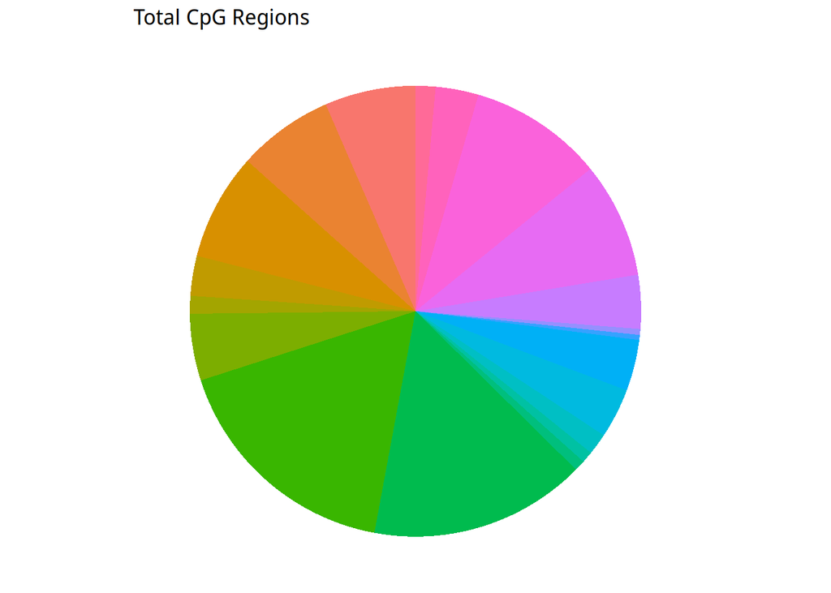

```r
# Count occurrences of total data
snp_meth_ld_counts <- snp.meth.merged.ld.a.b %>%
  dplyr::count(category)

#Count occurances in high LD data
snp_meth_highld_counts <- snp.meth.merged.ld.a.b.highld %>%
  dplyr::count(category)

# Pie Chart for `sea`
p2 <- ggplot(snp_meth_ld_counts, aes(x = "", y = n, fill = category)) +
  geom_bar(stat = "identity", width = 1) +
  coord_polar(theta = "y") +
  labs(title = "Total CpG Regions") +
  theme_void()  +
  theme(legend.position = "none")

p3 <- ggplot(snp_meth_highld_counts, aes(x = "", y = n, fill = category)) +
  geom_bar(stat = "identity", width = 1) +
  coord_polar(theta = "y") +
  labs(title = "High LD CpG Regions") +
  theme_void()

p2
```

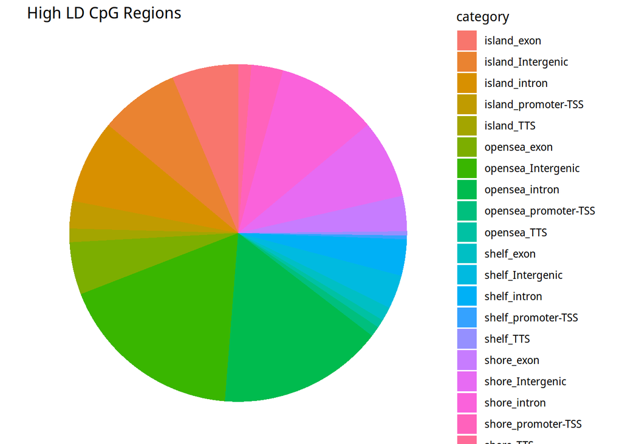

```r
p3
```

Above was a combination of island and region, now I want to look at each separately

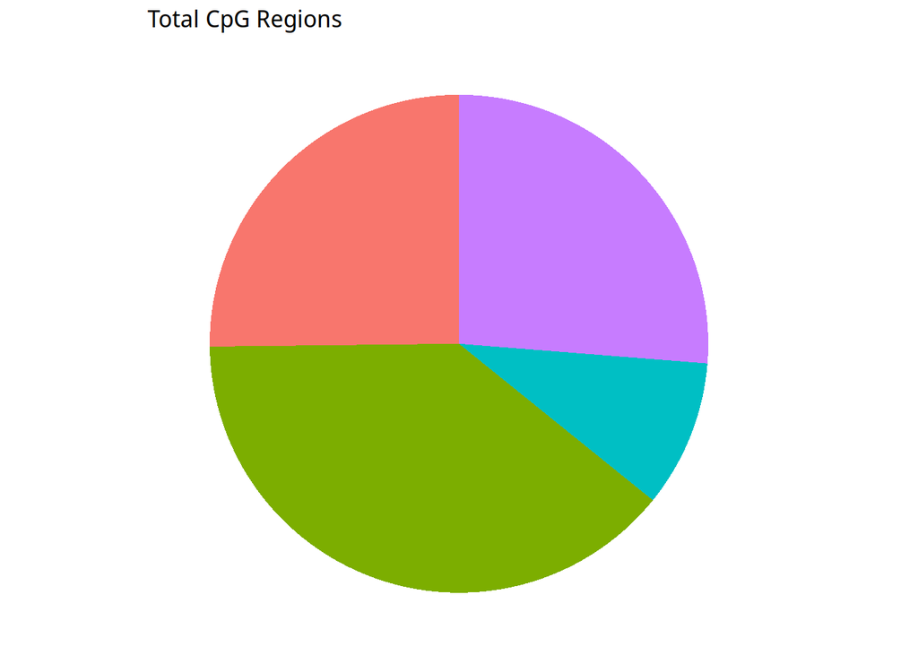

```r
###JUST region and annotation
snp.meth.merged.ld.a.b <- snp.meth.merged.ld.a.b %>%
  separate(Annotation, into = c("sea", "region"), sep = "_", remove = FALSE)
snp.meth.merged.ld.a.b.highld <- snp.meth.merged.ld.a.b.highld %>%
  separate(Annotation, into = c("sea", "region"), sep = "_", remove = FALSE)

# Count occurrences of total data
snp_meth_ld_sea <- snp.meth.merged.ld.a.b %>%
  dplyr::count(sea)

#Count occurances in high LD data
snp_meth_highld_sea <- snp.meth.merged.ld.a.b.highld %>%
  dplyr::count(sea)

# Pie Chart for `sea`
p4 <- ggplot(snp_meth_ld_sea, aes(x = "", y = n, fill = sea)) +
  geom_bar(stat = "identity", width = 1) +
  coord_polar(theta = "y") +
  labs(title = "Total CpG Regions") +
  theme_void()  +
  theme(legend.position = "none")

p5 <- ggplot(snp_meth_highld_sea, aes(x = "", y = n, fill = sea)) +
  geom_bar(stat = "identity", width = 1) +
  coord_polar(theta = "y") +
  labs(title = "High LD CpG Regions") +
  theme_void()


p4
```

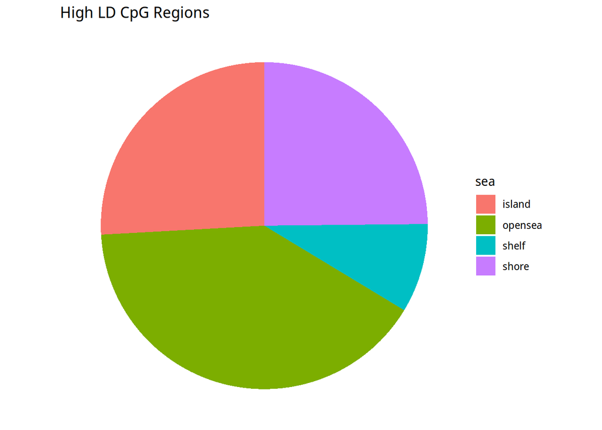

```r
p5
```

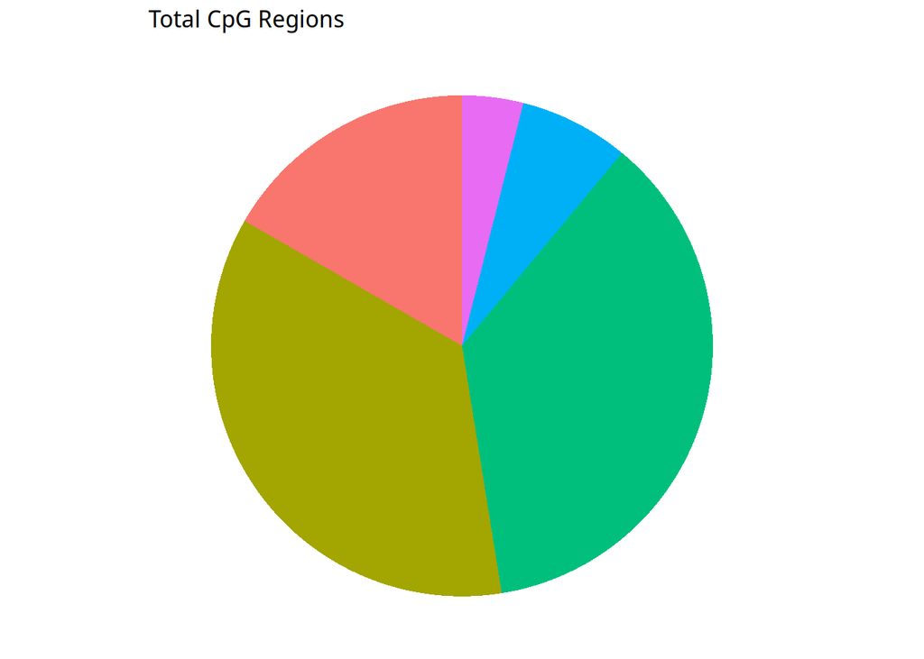

```r
# Count occurrences of total data
snp_meth_ld_region <- snp.meth.merged.ld.a.b %>%
  dplyr::count(region)

#Count occurances in high LD data
snp_meth_highld_region <- snp.meth.merged.ld.a.b.highld %>%
  dplyr::count(region)

# Pie Chart for `sea`
p6 <- ggplot(snp_meth_ld_region, aes(x = "", y = n, fill = region)) +
  geom_bar(stat = "identity", width = 1) +
  coord_polar(theta = "y") +
  labs(title = "Total CpG Regions") +
  theme_void()  +
  theme(legend.position = "none")

p7 <- ggplot(snp_meth_highld_region, aes(x = "", y = n, fill = region)) +
  geom_bar(stat = "identity", width = 1) +
  coord_polar(theta = "y") +
  labs(title = "High LD CpG Regions") +
  theme_void()


p6
```

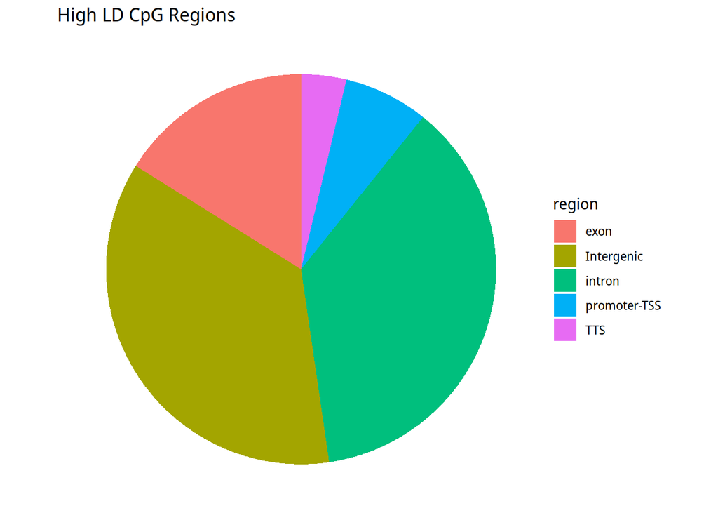

```r
p7
```

And again, look at how these occur via distance between loci.

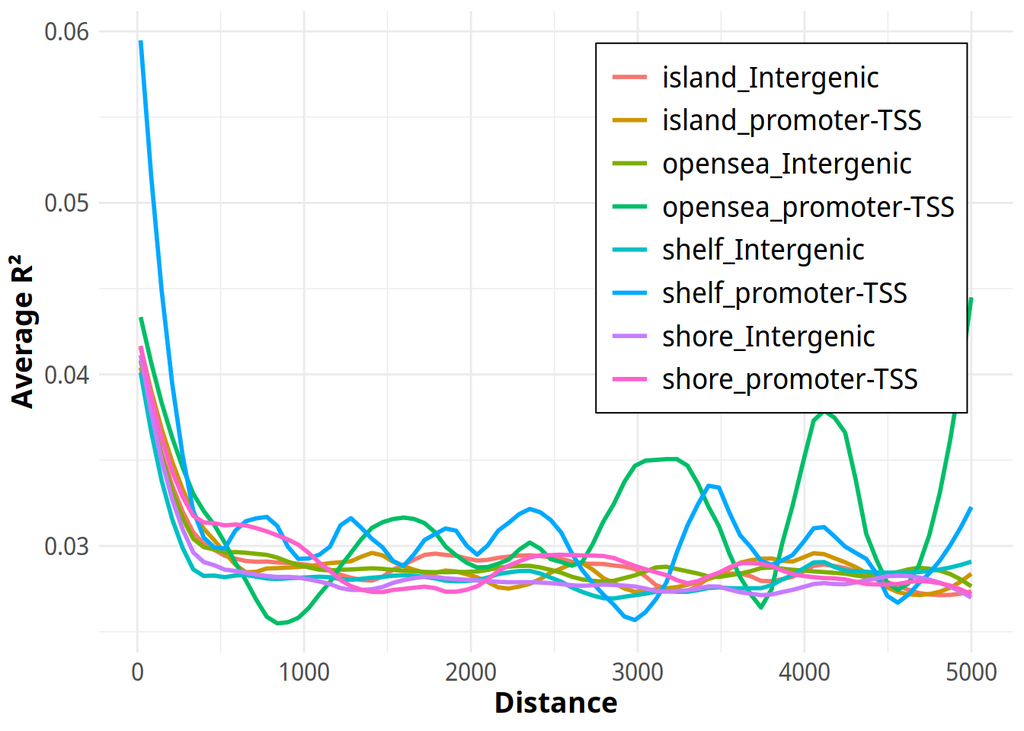

```r
###Calculate bins based on region
snp.meth.ld.5kb.category <- snp.meth.merged.ld.a.b %>%
  mutate(distance_bin = cut(distance,
                            breaks = seq(0, 5000, by = 20),
                            labels = seq(20, 5000, by = 20),
                            right = TRUE)) %>%
  mutate(distance_bin = as.numeric(as.character(distance_bin))) %>%
  group_by(distance_bin, category) %>% # Group by both distance_bin AND category
  summarise(avg_R2 = mean(R2, na.rm = TRUE), .groups = "drop")

snp.meth.ld.5kb.category <- snp.meth.ld.5kb.category %>%
  filter(!category %in% c("island_TTS", "island_exon", "island_intron", "opensea_TTS", "opensea_exon", "opensea_intron", "shelf_TTS", "shelf_exon", "shelf_intron", "shore_TTS", "shore_exon", "shore_intron", "NA"))

ggplot(snp.meth.ld.5kb.category, aes(x = distance_bin, y = avg_R2, color= category), na.rm=F) +
  #geom_point(alpha = 0.5, size=2) +  # Scatterplot of points
  geom_smooth(method = "loess", se = FALSE, span = 0.2) +  # Smoothed trend line
  #scale_color_manual(values= c("#e53207", "grey33", "#48497e"))+
  labs(title = "Linkage (5kb)",
       x = "Distance",
       y = "Average R²") +
  theme_minimal() +
  theme(legend.key.size = unit(0.75, "cm"), # Adjust size as needed
        legend.text = element_text(size = 14),
        legend.position = c(.95, .95),
        legend.justification = c("right", "top"),
        legend.box.just = "right",
        legend.box.background = element_rect(fill = "white", color = "black"),
        legend.margin = margin(6, 6, 6, 6),
        legend.title = element_blank(),
        axis.text=element_text(size=12),
        axis.title=element_text(size=14,face="bold"),
        plot.title = element_blank())
```

Plot only using region

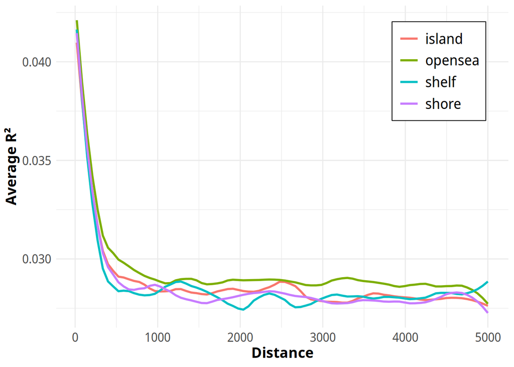

```r
###Calculate bins based on region
snp.meth.ld.5kb.sea <- snp.meth.merged.ld.a.b  %>%
  mutate(distance_bin = cut(distance,
                            breaks = seq(0, 5000, by = 20),
                            labels = seq(20, 5000, by = 20),
                            right = TRUE)) %>%
  mutate(distance_bin = as.numeric(as.character(distance_bin))) %>%
  group_by(distance_bin, sea) %>% # Group by both distance_bin AND category
  summarise(avg_R2 = mean(R2, na.rm = TRUE), .groups = "drop")

ggplot(snp.meth.ld.5kb.sea, aes(x = distance_bin, y = avg_R2, color= sea), na.rm=F) +
  #geom_point(alpha = 0.5, size=2) +  # Scatterplot of points
  geom_smooth(method = "loess", se = FALSE, span = 0.2) +  # Smoothed trend line
  #scale_color_manual(values= c("#e53207", "grey33", "#48497e"))+
  labs(title = "Linkage (5kb)",
       x = "Distance",
       y = "Average R²") +
  theme_minimal() +
  theme(legend.key.size = unit(0.75, "cm"), # Adjust size as needed
        legend.text = element_text(size = 14),
        legend.position = c(.95, .95),
        legend.justification = c("right", "top"),
        legend.box.just = "right",
        legend.box.background = element_rect(fill = "white", color = "black"),
        legend.margin = margin(6, 6, 6, 6),
        legend.title = element_blank(),
        axis.text=element_text(size=12),
        axis.title=element_text(size=14,face="bold"),
        plot.title = element_blank())
```

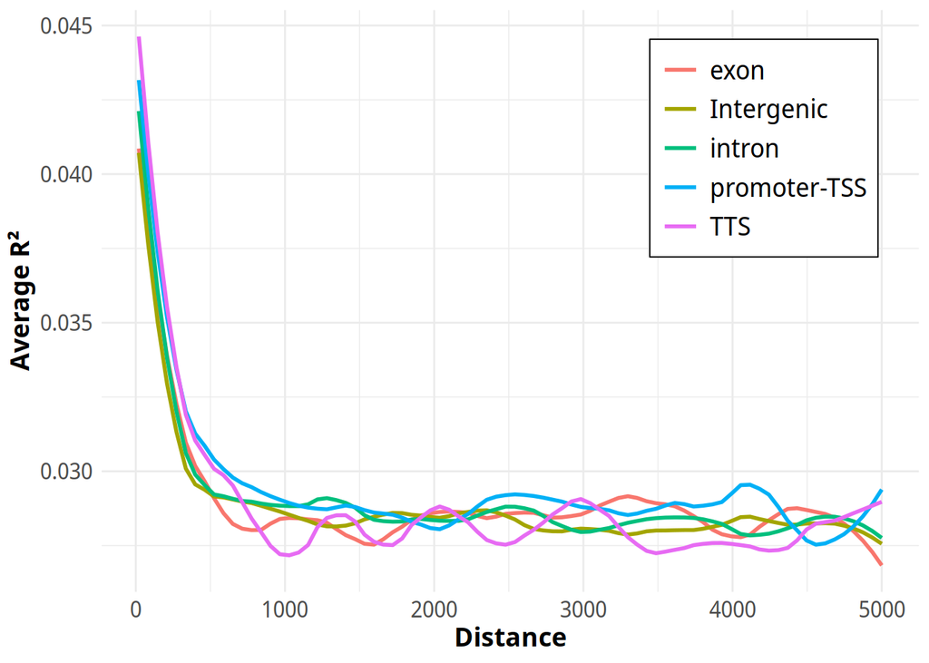

```r
###Calculate bins based on region
snp.meth.ld.5kb.region <- snp.meth.merged.ld.a.b %>%
  mutate(distance_bin = cut(distance,
                            breaks = seq(0, 5000, by = 20),
                            labels = seq(20, 5000, by = 20),
                            right = TRUE)) %>%
  mutate(distance_bin = as.numeric(as.character(distance_bin))) %>%
  group_by(distance_bin, region) %>% # Group by both distance_bin AND category
  summarise(avg_R2 = mean(R2, na.rm = TRUE), .groups = "drop")

ggplot(snp.meth.ld.5kb.region, aes(x = distance_bin, y = avg_R2, color= region), na.rm=F) +
  #geom_point(alpha = 0.5, size=2) +  # Scatterplot of points
  geom_smooth(method = "loess", se = FALSE, span = 0.2) +  # Smoothed trend line
  #scale_color_manual(values= c("#e53207", "grey33", "#48497e"))+
  labs(title = "Linkage (5kb)",
       x = "Distance",
       y = "Average R²") +
  theme_minimal() +
  theme(legend.key.size = unit(0.75, "cm"), # Adjust size as needed
        legend.text = element_text(size = 14),
        legend.position = c(.95, .95),
        legend.justification = c("right", "top"),
        legend.box.just = "right",
        legend.box.background = element_rect(fill = "white", color = "black"),
        legend.margin = margin(6, 6, 6, 6),
        legend.title = element_blank(),
        axis.text=element_text(size=12),
        axis.title=element_text(size=14,face="bold"),
        plot.title = element_blank())
```